# Racial/ethnic Exposure

This metric measures the exposure of a given race/ethnicity group to other race/ethnicity groups. The metric is calculated at the Census tract level and then aggregated to the county level. We are interested in Hispanic, non-Hispanic Black, non-Hispanic white, and Other Races and Ethnicities.

1. On average, people who are Hispanic live in neighborhoods that are X% non-Hispanic.
2. On average, people who are non-Hispanic Black live in neighborhoods that are X% non-non-Hispanic Black.
3. On average, people who are non-Hispanic white live in neighborhoods that are X% non-non-Hispanic white.
4. On average, people who are Other Races and Ethnicities live in neighborhoods that are x% non-Other Races and Ethnicities.

**Process:**

1. Pull all non-overlapping race/ethnicity groups needed to create Hispanic, non-Hispanic Black, non-Hispanic white, and Other Races and Ethnicities.
2. Collapse the detailed groups to the four groups of interest.
3. Calculate the share of a county’s racial/ethnic group in each tract.
4. Calculate exposure to other racial/ethnic groups:
   - Calculate Hispanic exposure to other three groups.
   - Calculate non-Hispanic Black exposure to other three groups.
   - Calculate non-Hispanic white exposure to other three groups.
   - Calculate Other Races and Ethnicities exposure to other three groups.
5. Validation
6. Add data quality flags
7. Save the data

```r
options(scipen = 999)

library(tidyverse)
library(censusapi)
library(urbnthemes)
library(reactable)

set_urbn_defaults(style = "print")

source(here::here("06_neighborhoods", "R", "census_api_key.R"))
source(here::here("06_neighborhoods", "R", "get_vars.R"))
```

## 2018 ACS 5-Year Estimates

### 1. Pull all non-overlapping race/enthnicity groups needed to create Hispanic, non-Hispanic Black, non-Hispanic white, and Other Races and Ethnicities.

The American Community Survey reports detailed race and ethnicity by the following table.

[figure not shown]

We pull all of the race/ethnicity counts for 2018 using `library(censusapi)`. **Note:** This will require a [Census API key](https://api.census.gov/data/key_signup.html). Add the key to `census_api_key-template.R` and then delete then delete “template”. It is sourced above.

```r
# variables of interest
vars <- c(
  # Hispanic or Latino
  "DP05_0071E", # Estimate!!HISPANIC OR LATINO AND RACE!!Total population!!Hispanic or Latino (of any race)
  "DP05_0071M",
  # Not Hispanic or Latino
  "DP05_0077E", # White alone
  "DP05_0077M", # White alone MOE
  "DP05_0078E", # Black or African American alone
  "DP05_0078M", # Black or African American alone MOE
  "DP05_0079E", # American Indian and Alaska Native alone
  "DP05_0079M", # American Indian and Alaska Native alone MOE
  "DP05_0080E", # Asian alone
  "DP05_0080M", # Asian alone MOE
  "DP05_0081E", # Native Hawaiian and Other Pacific Islander alone
  "DP05_0081M", # Native Hawaiian and Other Pacific Islander alone MOE
  "DP05_0082E", # Some other race alone
  "DP05_0082M", # Some other race alone
  "DP05_0083E", # Two or more races
  "DP05_0083M"  # Two or more races MOE
)

# pull Census tracts for 2018
# note: get_vars also pulls people counts for tracts
tracts <- get_vars(year = 2018, vars = vars, geography = "tract")

# rename the variables
tracts <- tracts %>%
  rename(
    people = B01003_001E, # from get_vars()
    hispanic = DP05_0071E,
    hispanic_moe = DP05_0071M,
    white_nh = DP05_0077E,
    white_nh_moe = DP05_0077M,
    black_nh = DP05_0078E,
    black_nh_moe = DP05_0078M,
    aian_nh = DP05_0079E,
    aian_nh_moe = DP05_0079M,
    asian_nh = DP05_0080E,
    asian_nh_moe = DP05_0080M,
    nhpi_nh = DP05_0081E,
    nhpi_nh_moe = DP05_0081M,
    other_nh = DP05_0082E,
    other_nh_moe = DP05_0082M,
    two_or_more_nh = DP05_0083E,
    two_or_more_nh_moe = DP05_0083M
  )
```

Other Races and Ethnicities includes Non-Hispanic American Indian and Alaska Native alone (`aian_nh`), Non-Hispanic Asian alone (`asian_nh`), non-Hispanic Native Hawaiian and Other Pacific Island alone (`nhpi_nh`), non-Hispanic other (`other_nh`), and non-Hispanic two or more (`two_or_more_nh`).

```r
tracts <- tracts %>%
  mutate(other_nh =
           aian_nh +
           asian_nh +
           nhpi_nh +
           other_nh +
           two_or_more_nh) %>%
  select(state, county, tract, people, hispanic, black_nh, other_nh, white_nh)
```

**Check:** Do the pulled race/ethnicity counts sum to the tract populations?

```r
stopifnot(
  tracts %>%
    mutate(people2 = hispanic + black_nh + other_nh + white_nh) %>%
    filter(people != people2) %>%
    nrow() == 0
)
```

### 3. Calculate the share of a county’s racial/ethnic group in each tract

```r
indices <- tracts %>%
  group_by(state, county) %>%
  mutate(
    share_of_black_nh = black_nh / sum(black_nh),
    share_of_hispanic = hispanic / sum(hispanic),
    share_of_white_nh = white_nh / sum(white_nh),
    share_of_other_nh = other_nh / sum(other_nh)
    ) %>%
  ungroup()
```

**Check:** Do the shares in each tract sum to one in a county?

```r
stopifnot(
  indices %>%
    group_by(state, county) %>%
    summarize(
      share_of_hispanic = sum(share_of_hispanic),
      share_of_white_nh = sum(share_of_white_nh),
      share_of_black_nh = sum(share_of_black_nh),
      share_of_other_nh = sum(share_of_other_nh)
    ) %>%
    filter(!near(share_of_white_nh, 1) | !near(share_of_black_nh, 1) | !near(share_of_hispanic, 1)) %>%
    nrow() == 0
)
```

### 4. Calculate exposure to other racial/ethnic groups

- Calculate non-Hispanic Black exposure to the other groups.
- Calculate Hispanic exposure to the other groups.
- Calculate non-Hispanic white exposure to the other groups.
- Calculate Other Races and Ethnicities exposure to the other groups.

> Focusing just on whites for simplicity, we want to compute the average share of neighbors who are non-white. Thus for each census tract in a county, we need to know the percentage non-white.

Calculate the complement to each race/ethnic group of interest.

```r
indices <- indices %>%
  mutate(
    non_white_nh = (hispanic + black_nh + other_nh) / people,
    non_black_nh = (hispanic + white_nh + other_nh) / people,
    non_hispanic = (white_nh + black_nh + other_nh) / people,
    non_other_nh = (hispanic + white_nh + black_nh) / people
    )
```

> We would then take the weighted average across tracts with the weight being the percentage of a county’s whites living in each tract. So in a county with only 2 tracts, one tract has 80 whites and only 10 percent of that residents are non-white and in the second tract there are 20 white residents but 50% of the tract is non-white, the white to non-white index would be 0.8*0.1 + 0.2*0.5 = 0.18. In other words the average white resident lives in a neighborhood in which 18% of his neighbors are non-white

We find the weighted average at the county level of exposure to other race/ethnicity groups weighted by the share of the race/ethnicity group living in each tract. In other words, the 0.1 and 0.5 are `non_white_nh` and the 0.8 and 0.2 are `share_of_white_nh`.

```r
county_data <- indices %>%
  group_by(state, county) %>%
  summarize(
    tracts = n(),
    people = sum(people),
    hispanic = sum(hispanic),
    black_nh = sum(black_nh),
    white_nh = sum(white_nh),
    other_nh = sum(other_nh),
    white_nh_exposure = weighted.mean(non_white_nh, w = share_of_white_nh),
    black_nh_exposure = weighted.mean(non_black_nh, w = share_of_black_nh),
    hispanic_exposure = weighted.mean(non_hispanic, w = share_of_hispanic),
    other_nh_exposure = weighted.mean(non_other_nh, w = share_of_other_nh)
  ) %>%
  ungroup()
```

### 5. Validation

The table shows the calculated metrics. Click on the variable columns to sort the table.

| FIPS | tracts | hispanic | black_nh | white_nh | other_nh | hispanic_exp | black_nh_exp | white_nh_exp | other_nh_exp |
| --- | --- | --- | --- | --- | --- | --- | --- | --- | --- |
| 01001 | 12 | 1528 | 10475 | 41412 | 1785 | 0.929 | 0.74 | 0.233 | 0.958 |
| 01003 | 32 | 9353 | 19529 | 172768 | 6457 | 0.924 | 0.8 | 0.158 | 0.958 |
| 01005 | 9 | 1106 | 12199 | 11898 | 579 | 0.935 | 0.49 | 0.51 | 0.97 |
| 01007 | 4 | 547 | 4974 | 16801 | 205 | 0.964 | 0.615 | 0.198 | 0.987 |
| 01009 | 9 | 5261 | 820 | 50232 | 1332 | 0.852 | 0.97 | 0.121 | 0.972 |
| 01011 | 3 | 51 | 7893 | 2228 | 180 | 0.994 | 0.213 | 0.717 | 0.969 |
| 01013 | 9 | 67 | 9027 | 10384 | 547 | 0.991 | 0.448 | 0.396 | 0.95 |
| 01015 | 31 | 4203 | 23618 | 83423 | 3854 | 0.909 | 0.607 | 0.218 | 0.942 |
| 01017 | 9 | 768 | 13319 | 18872 | 867 | 0.948 | 0.558 | 0.409 | 0.961 |
| 01019 | 6 | 398 | 1267 | 23730 | 458 | 0.979 | 0.939 | 0.081 | 0.974 |

[output cut: 3132 more lines]

**Check:** Is the metric bound by 0 and 1?

```r
stopifnot(
  county_data %>%
    filter(white_nh_exposure > 1 | white_nh_exposure < 0 |
             black_nh_exposure > 1 | black_nh_exposure < 0 |
             hispanic_exposure > 1 | hispanic_exposure < 0 |
             other_nh_exposure > 1 | other_nh_exposure < 0) %>%
    nrow() == 0
)
```

**Check:** Do groups with zero representation in a county have an `NA` for the exposure metric?

```r
stopifnot(
  county_data %>%
    filter(hispanic == 0 & !is.na(hispanic_exposure)) %>%
    nrow() == 0
)

stopifnot(
  county_data %>%
    filter(black_nh == 0 & !is.na(black_nh_exposure)) %>%
    nrow == 0
)

stopifnot(
  county_data %>%
    filter(white_nh == 0 & !is.na(white_nh_exposure)) %>%
    nrow() == 0
)

stopifnot(
  county_data %>%
    filter(other_nh == 0 & !is.na(other_nh_exposure)) %>%
    nrow() == 0
)
```

**Check:** How many missing values are there?

Values are missing where the count in the racial group is 0. For example, `black_nh_exposure` is `NA` when `black_nh == 0`.

```r
map_dbl(county_data, ~sum(is.na(.)))
```

```
##             state            county            tracts            people
##                 0                 0                 0                 0
##          hispanic          black_nh          white_nh          other_nh
##                 0                 0                 0                 0
## white_nh_exposure black_nh_exposure hispanic_exposure other_nh_exposure
##                 0                96                14                11
```

Let’s visualize the relationship between a group’s share of the population in a county and the calculated exposure metric.

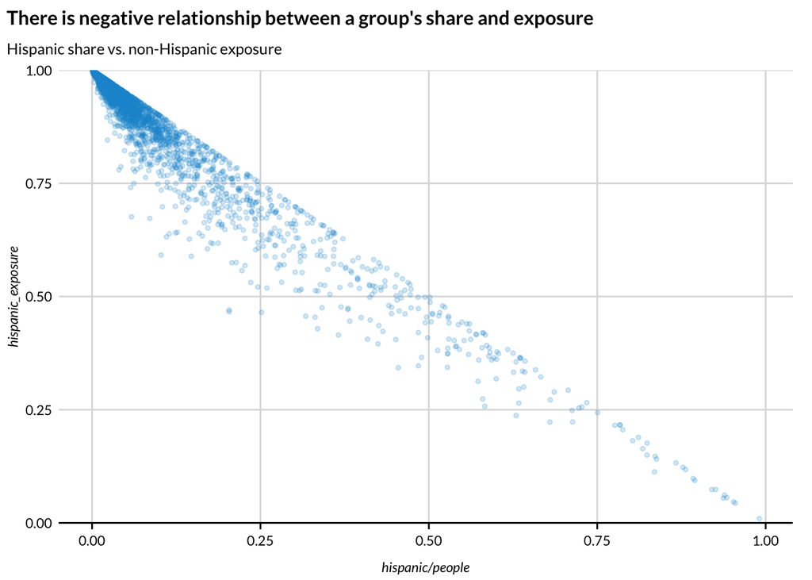

```r
county_data %>%
  ggplot(aes(hispanic / people, hispanic_exposure)) +
  geom_point(alpha = 0.2,
             size = 1) +
  scale_y_continuous(expand = c(0, 0),
                     limits = c(0, 1)) +
  labs(title = "There is negative relationship between a group's share and exposure",
       subtitle = "Hispanic share vs. non-Hispanic exposure") +
  scatter_grid()
```

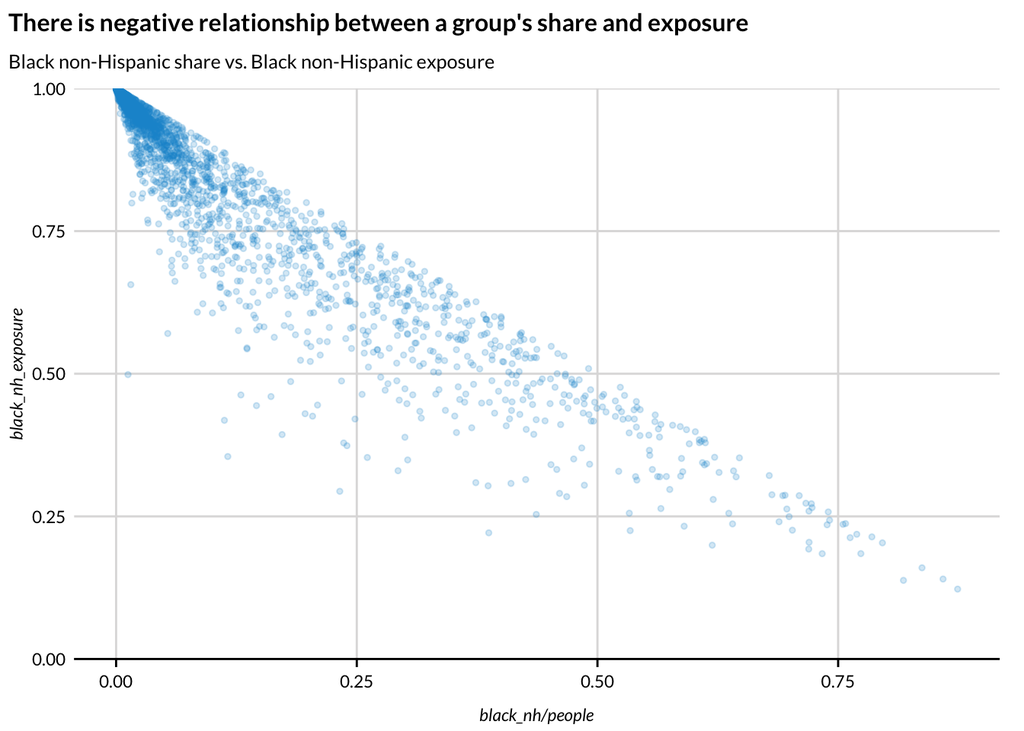

```r
county_data %>%
  ggplot(aes(black_nh / people, black_nh_exposure)) +
  geom_point(alpha = 0.2,
             size = 1) +
  scale_y_continuous(expand = c(0, 0),
                     limits = c(0, 1)) +
  labs(title = "There is negative relationship between a group's share and exposure",
       subtitle = "Black non-Hispanic share vs. Black non-Hispanic exposure") +
  scatter_grid()
```

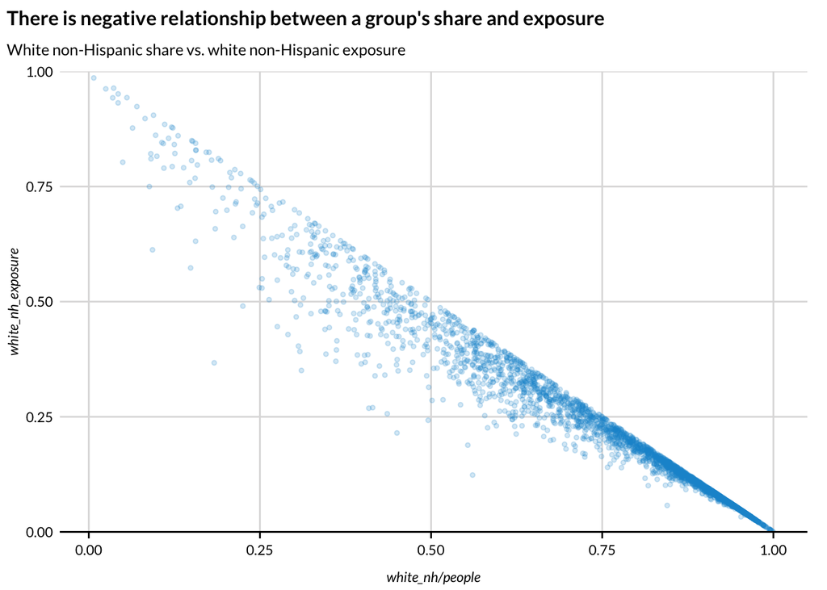

```r
county_data %>%
  ggplot(aes(white_nh / people, white_nh_exposure)) +
  geom_point(alpha = 0.2,
             size = 1) +
  scale_y_continuous(expand = c(0, 0),
                     limits = c(0, 1)) +
  labs(title = "There is negative relationship between a group's share and exposure",
       subtitle = "White non-Hispanic share vs. white non-Hispanic exposure") +
  scatter_grid()
```

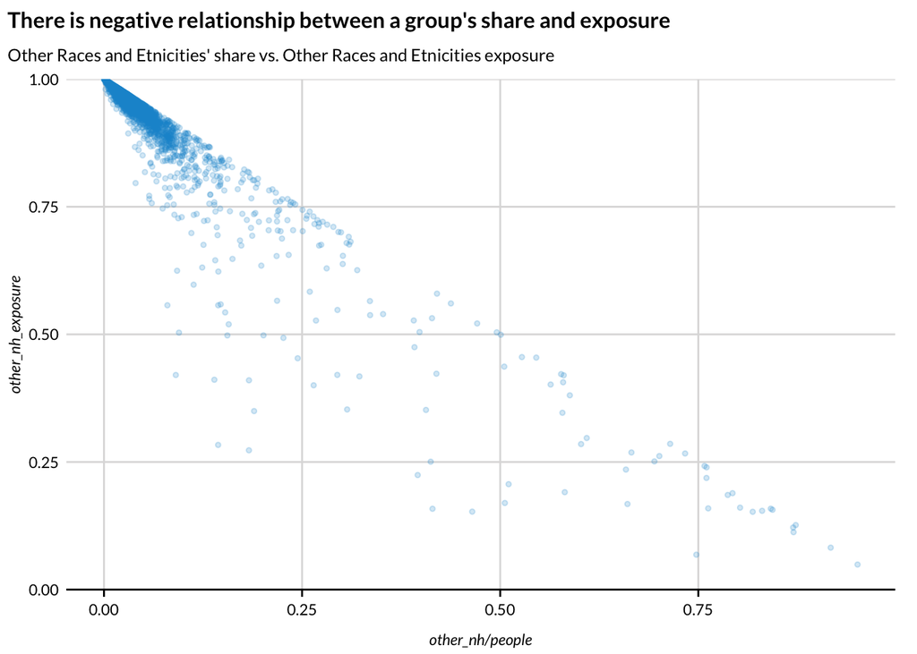

```r
county_data %>%
  ggplot(aes(other_nh / people, other_nh_exposure)) +
  geom_point(alpha = 0.2,
             size = 1) +
  scale_y_continuous(expand = c(0, 0),
                     limits = c(0, 1)) +
  labs(title = "There is negative relationship between a group's share and exposure",
       subtitle = "Other Races and Etnicities' share vs. Other Races and Etnicities exposure") +
  scatter_grid()
```

### 6. Add Data Quality Flags

We need to add data quality flags with `1`, `2`, or `3`. The values are outlined in the [data standards](https://github.com/UI-Research/gates-mobility-metrics).

- `1` - otherwise
- `3` - if 5 or fewer people. The cutoff of 5, which was reached through correspondence, is a little arbitrary.

We currently don’t use `2` for these metrics.

```r
#' Assign a data quality flag
#'
#' @param race A vector of counts of a race/ethnicity group within a county
#' @param exposure A race/ethnicity exposure metric
#'
#' @return A numeric data quality flag
#'
set_quality <- function(race, exposure) {

  quality <- case_when(
    race > 5 ~ 1,
    race <= 5 ~ 3
  )

  quality <- if_else(is.na(exposure), as.numeric(NA), quality)

  return(quality)

}

county_data <- county_data %>%
  mutate(hispanic_exposure_quality = set_quality(hispanic, hispanic_exposure)) %>%
  mutate(black_nh_exposure_quality = set_quality(black_nh, black_nh_exposure)) %>%
  mutate(white_nh_exposure_quality = set_quality(white_nh, white_nh_exposure)) %>%
  mutate(other_nh_exposure_quality = set_quality(other_nh, white_nh_exposure))


count(county_data, hispanic_exposure_quality)
```

```
## # A tibble: 3 x 2
##   hispanic_exposure_quality     n
##                       <dbl> <int>
## 1                         1  3119
## 2                         3     9
## 3                        NA    14
```

```r
count(county_data, black_nh_exposure_quality)
```

```
## # A tibble: 3 x 2
##   black_nh_exposure_quality     n
##                       <dbl> <int>
## 1                         1  2948
## 2                         3    98
## 3                        NA    96
```

```r
count(county_data, white_nh_exposure_quality)
```

```
## # A tibble: 1 x 2
##   white_nh_exposure_quality     n
##                       <dbl> <int>
## 1                         1  3142
```

```r
count(county_data, other_nh_exposure_quality)
```

```
## # A tibble: 2 x 2
##   other_nh_exposure_quality     n
##                       <dbl> <int>
## 1                         1  3110
## 2                         3    32
```

### 7. Save the Data

We need to include all counties in the published data even if we don’t have a metric for the county. We load the county file and join our metrics to the county file.

```r
# load the 2018 county file
all_counties <- read_csv(here::here("geographic-crosswalks", "data", "county-file.csv")) %>%
  filter(year == 2018)

county_data <- full_join(county_data, all_counties, by = c("state", "county"))

county_data %>%
  mutate(year = 2018) %>%
  select(year,
         state,
         county,
         hispanic_exposure,
         hispanic_exposure_quality,
         black_nh_exposure,
         black_nh_exposure_quality,
         white_nh_exposure,
         white_nh_exposure_quality,
         other_nh_exposure,
         other_nh_exposure_quality
  ) %>%
  write_csv(here::here("06_neighborhoods", "race-ethnicity-exposure", "race-ethnicity-exposure.csv"))
```